# A New Tennis Era or Just a Stroke of Luck?

## Rodz Andrie Amor, Summer 2023

[figure not shown]

## Background and Motivation

Held in England, Wimbledon is regarded as one of the most prestiguous and historic tennis championships along with the Australian Open, the French Open, and the United States Open. Wimbledon is played on a grass surface and is the oldest annual tennis tournament with centuries of tradition and history. Started in 2003 by Roger Federer, the recent tennis climate has been dominated by what is colloquially coined "The Big Four" players, which are Roger Federer, Rafeal Nadal, Novak Djokovic, and Andy Murray. The past 19 years of tennis were a heap of intense rivalry between these four players as they alternated taking the tile of tennis world champion. A overview of the history of Wimbledon can be found in this [Wikipedia](https://en.wikipedia.org/wiki/List_of_Wimbledon_gentlemen%27s_singles_champions) page.

[figure not shown]

However, was this truly the start of a new era of tennis or was this just a surprising upset. After all, the match was too close to decide, as the advantage seemed to alternate between both players. That question is what I want to investigate for this CMSC 320 final tutorial. In this tutorial, I will walk you through the entire data science pipeline to arrive at the insight to answer this question.

Interestingly enough, the first rematch between Carlos Alcaraz and Novak Djokovich after the championship is on the due date of this tutorial, which is August 20, 2023. Unfortunately, I plan to submit this assignment before the match takes place. However, in this tutorial, I will be constructing a predictive model to predict the outcome of the rematch. Join me and let us see whether the predictive model will be able to predict the winner correctly!

By the end of this tutorial, you should know how to:

1. Extract and collect data through webscraping html tables
2. Clean and reorganize data into a useable format
3. Be able to summarize statistics on the data gathered
4. Make visualizations and comparative analysis on the data
5. Model the data and make a Logistic Regression model for binary classification
6. Train the model with data
7. Make some insights on the model and outcome

More Resources on Tennis Statistics

- [Ultimate Tennis Tactics](https://www.ultimatetennisstatistics.com/) - Additional tennis data and statistics and forecasts provided
- [Tennis.com](https://www.tennis.com/) - Tennis news website
- [Association of Tennis Professionals](https://www.atptour.com/en/)
- [Data Science Process](https://www.springboard.com/blog/data-science/data-science-process/)

## Required Libraries/Frameworks

The following libraries are necessary for this data analysis and visualization in this project. If you find that you are missing any of the packages, you can install them into your machine with the command `pip install [package-name]`. Furthermore, if you want the program to work in any machin or environment, you can use python virtual evironments with the command `python3 -m venv venv` and `source venv/bin/activate` for MacOS or `\venv\Scripts\activate` for Windows.

Information and the purpose of each library is listed below:

- `numpy` - a data analysis library used to work with n-dimensional arrays
- `pandas` - a data analysis toolkit used to work with table like data structures
- `requests` - library that helps with web scraping and making REST requests
- `BeautifulSoup` - tool that help in the process of web scraping
- `matplotlib.pylplot` - data visualization tools
- `seaborn` - additional data visualization tools
- `sklearn` - several machine learning functions such as splitting training data or getting linear or logistic models.

```python
# Data Collection
import requests
from bs4 import BeautifulSoup

# Data Operations
import numpy as np
import pandas as pd

# Data Visualization
import matplotlib.pyplot as plt
import seaborn as sns

# Machine Learning and Prediction
from sklearn.linear_model import LogisticRegression
from sklearn.model_selection import train_test_split
from sklearn.metrics import accuracy_score
```

## Part 1: Data Collection

*Note: To be concise, I will only be printing out the output for Carlos Alcaraz, as the data for both players will have identical structures.*

```python
# URLs that have tables of data
alcaraz_url = "https://www.minorleaguesplits.com/tennisabstract/cgi-bin/frags/CarlosAlcaraz.js"
djokovic_url = "https://www.minorleaguesplits.com/tennisabstract/cgi-bin/frags/NovakDjokovic.js"

# Perform a GET request to get the html of the data
# User Agent headers are necessary to get past the server blocking the request
alcaraz_data = requests.get(alcaraz_url, headers={"User-Agent": "XY"})
djokovic_data = requests.get(djokovic_url, headers={"User-Agent": "XY"})

# Convert it to BeatifulSoup to perform operations
alcaraz_root = BeautifulSoup(alcaraz_data.content, "html.parser")
djokovic_root = BeautifulSoup(djokovic_data.content, "html.parser")

# Uncomment if you want to see the output
# print(alcaraz_root.prettify())
# print(djokovic_root.prettify())
```

We will need to perform web scraping for two different html files. The first HTML file holds overall data on the player such as their overall performance over a 52 week or career period. However, that data will not be sufficient to train a machine learning model on the players. As a result, the web scraping below will be grabbing data on every match the player has finished. This will allow us to train a model and make a prediction on the outcome of two different players in a match.

Furthermore, since the table data is filled by JavaScript after the page is already loaded, the web scraping part will not be as simple to gather the tabular data. As a result, I have saved the HTML and saved it into a file named "alcaraz_matches.html" and "djokovic_matches.html" after it has loaded the necessary information.

You can find the links to the tables here:

- [Alcaraz Matches](https://www.tennisabstract.com/cgi-bin/player-classic.cgi?p=CarlosAlcaraz&f=Acx2018021220230812qq)
- [Djokovic Matches](https://www.tennisabstract.com/cgi-bin/player-classic.cgi?p=CarlosAlcaraz&f=ACareerqq)

```python
# URLs that have tables of data
alcaraz_match_path = "alcaraz_matches.html"
djokovic_match_path = "djokovic_matches.html"

alcaraz_matches = pd.read_html(alcaraz_match_path)[0]
djokovic_matches = pd.read_html(djokovic_match_path)[0]

# Renamed unnamed column to be the outcome of match
alcaraz_matches = alcaraz_matches.rename(columns={"Unnamed: 6": "Outcome"})
djokovic_matches = djokovic_matches.rename(columns={"Unnamed: 6": "Outcome"})

print(alcaraz_matches.shape)
alcaraz_matches.head()

alcaraz_matches.to_csv("alcaraz_matches.csv")
djokovic_matches.to_csv("djokovic_matches.csv")
```

```
(274, 17)
```

### Relevant Tables

For their ranking, the primary features that we are the most concerned with is their ATP ranking, points scored, ELO rank, and ELO. We will be primarily investigating three sets of tables for each player and making comparisons. The reason for each table is listed below:

End Of Year Rankings - Used to see how ratings of each players change over the years and determine if there is a trend

Last 52 Week Splits - Recent past year (52 week) performance are very indicative of the trajectory of future performance

Entire Career Splits - The career splits are used as a baseline to see the overall performance of these players throughout their careers

After obtaining this data, we will be analyzing the change in these features over time. Next, we will be looking at the 52 week split, which is their past year of performance. We will be looking at their performance for each split and surface. Then, we will be comparing these statistics for both of these players and making predictions. Furthermore, we will be using their recent performance to be more indicative of their future performance.

```python
# Get the three tables for Carlos Alcaraz
alcaraz_year_rankings = alcaraz_root.findAll('table', id='year-end-rankings')
alcaraz_52_splits = alcaraz_root.findAll('table', id='last52-splits')
alcaraz_career_splits = alcaraz_root.findAll('table', id='career-splits')

# Get the three tables for Novak Djokovic
djokovic_year_rankings = djokovic_root.findAll('table', id='year-end-rankings')
djokovic_52_splits = djokovic_root.findAll('table', id='last52-splits')
djokovic_career_splits = djokovic_root.findAll('table', id='career-splits')

# Get match data for both Alacarz and Djokovic
# This will be used later in the further insight and prediction section of this tutorial
alcaraz_match_stats = alcaraz_root.findAll('table', id='year-end-rankings')
djokovic_match_stats = djokovic_root.findAll('table', id='year-end-rankings')

# Convert the three tables for each player into pandas dataframes
# We are getting the first one because it returns a list of exactly 1 element
alcaraz_year_rankings = pd.read_html(str(alcaraz_year_rankings))[0]
alcaraz_52_splits = pd.read_html(str(alcaraz_52_splits))[0]
alcaraz_career_splits = pd.read_html(str(alcaraz_career_splits))[0]

djokovic_year_rankings = pd.read_html(str(djokovic_year_rankings))[0]
djokovic_52_splits = pd.read_html(str(djokovic_52_splits))[0]
djokovic_career_splits = pd.read_html(str(djokovic_career_splits))[0]
```

```python
print(alcaraz_year_rankings.shape)
alcaraz_year_rankings.head()
```

```
(5, 15)
```

|  | Year | ATP Rank | Points | Elo Rank | Elo | hElo Rank | hElo | cElo Rank | cElo | gElo Rank | gElo | Doubles: ATP Rank | Points.1 | D-Lo Rank | D-Lo |
| --- | --- | --- | --- | --- | --- | --- | --- | --- | --- | --- | --- | --- | --- | --- | --- |
| 0 | Current (2023-08-14) | 1 | 9395 | 1 | 2215 | 2.0 | 2118.0 | 1 | 2127 | 1.0 | 2062.0 | NaN | NaN | NaN | NaN |
| 1 | 2022 | 1 | 6820 | 3 | 2126 | 3.0 | 2069.0 | 3 | 2071 | 8.0 | 1849.0 | NaN | NaN | NaN | NaN |
| 2 | 2021 | 32 | 1612 | 6 | 2030 | 6.0 | 1970.0 | 8 | 1932 | 27.0 | 1736.0 | NaN | NaN | NaN | NaN |
| 3 | 2020 | 141 | 464 | 51 | 1766 | NaN | NaN | 37 | 1742 | NaN | NaN | NaN | NaN | NaN | NaN |
| 4 | 2019 | 492 | 60 | 288 | 1450 | 368.0 | 1320.0 | 242 | 1445 | NaN | NaN | NaN | NaN | NaN | NaN |

```python
print(alcaraz_52_splits.shape)
alcaraz_52_splits.head()
```

```
(14, 23)
```

|  | Split | M | W | L | Win% | Set W-L | Set% | Game W-L | Game% | TB W-L | ... | Brk% | A% | DF% | 1stIn | 1st% | 2nd% | SPW | RPW | TPW | DR |
| --- | --- | --- | --- | --- | --- | --- | --- | --- | --- | --- | --- | --- | --- | --- | --- | --- | --- | --- | --- | --- | --- |
| 0 | Hard | 39 | 31 | 8 | 79.5% | 72-28 | 72.0% | 564-442 | 56.1% | 14-8 | ... | 28.9% | 5.0% | 3.4% | 65.7% | 71.1% | 56.2% | 66.0% | 40.8% | 52.9% | 1.20 |
| 1 | Clay | 28 | 25 | 3 | 89.3% | 57-13 | 81.4% | 400-254 | 61.2% | 3-3 | ... | 39.6% | 4.8% | 2.5% | 67.3% | 69.9% | 56.2% | 65.4% | 45.3% | 55.0% | 1.31 |
| 2 | Grass | 12 | 12 | 0 | 100.0% | 31-5 | 86.1% | 210-144 | 59.3% | 4-1 | ... | 26.3% | 6.5% | 3.5% | 64.3% | 76.2% | 55.1% | 68.7% | 40.5% | 54.2% | 1.29 |
| 3 | Grand Slams | 20 | 19 | 1 | 95.0% | 57-15 | 79.2% | 409-277 | 59.6% | 5-5 | ... | 33.7% | 5.1% | 3.2% | 67.1% | 71.2% | 57.3% | 66.6% | 43.2% | 54.5% | 1.30 |
| 4 | Masters | 33 | 27 | 6 | 81.8% | 57-18 | 76.0% | 427-317 | 57.4% | 11-5 | ... | 27.3% | 6.1% | 3.3% | 64.6% | 73.1% | 58.0% | 67.7% | 40.4% | 53.4% | 1.25 |

5 rows × 23 columns

```python
print(alcaraz_career_splits.shape)
alcaraz_career_splits.head()
```

```
(14, 23)
```

|  | Split | M | W | L | Win% | Set W-L | Set% | Game W-L | Game% | TB W-L | ... | Brk% | A% | DF% | 1stIn | 1st% | 2nd% | SPW | RPW | TPW | DR |
| --- | --- | --- | --- | --- | --- | --- | --- | --- | --- | --- | --- | --- | --- | --- | --- | --- | --- | --- | --- | --- | --- |
| 0 | Hard | 84 | 63 | 21 | 75.0% | 143-65 | 68.8% | 1147-924 | 55.4% | 26-18 | ... | 29.0% | 4.9% | 3.1% | 64.5% | 70.9% | 56.1% | 65.7% | 40.5% | 52.7% | 1.18 |
| 1 | Clay | 78 | 64 | 14 | 82.1% | 148-54 | 73.3% | 1119-804 | 58.2% | 19-12 | ... | 35.6% | 3.5% | 2.7% | 66.1% | 69.8% | 53.8% | 64.4% | 43.6% | 53.6% | 1.22 |
| 2 | Grass | 18 | 16 | 2 | 88.9% | 44-15 | 74.6% | 324-253 | 56.2% | 7-2 | ... | 23.9% | 7.2% | 3.6% | 63.9% | 74.5% | 54.1% | 67.1% | 39.3% | 52.7% | 1.20 |
| 3 | Grand Slams | 44 | 36 | 8 | 81.8% | 113-46 | 71.1% | 875-653 | 57.3% | 13-12 | ... | 31.3% | 5.5% | 3.0% | 65.6% | 70.8% | 56.3% | 65.8% | 41.5% | 53.2% | 1.22 |
| 4 | Masters | 59 | 45 | 14 | 76.3% | 98-39 | 71.5% | 774-608 | 56.0% | 19-12 | ... | 28.0% | 4.8% | 3.3% | 64.4% | 71.9% | 55.1% | 65.9% | 40.7% | 52.7% | 1.19 |

5 rows × 23 columns

### Explanation of Data

Split - Either the court surface or the type of tournament

M - # of matches played

W - # of wins

L - # of losses

Set W-L - Record of sets won and loss

Set% - % of sets won

Game W-L - Record of games won and loss

TB W-L - Record of tiebreaks won and loss

MS - # of matches won on straight sets

Hld% - % of service games held

Brk% - % of service games broken

A% - Ace Percentage

DF% - % of double faults

1stIn - % of first serves that were in

1st% - % of points won on first serve

2nd% - % of points won on second serve

SPW - Service points won %

RPW - Return points won %

TPW - Total points won %

## Part 2: Data Processing

The next step of the data analysis process is to perform data cleaning and data tidying. We will be handling data by changing the structure into a format that is easier to perform operations and analysis.

### Data Cleaning and Tidying

The first step we will be taking is to remove and drop the columns that will not be relevant for our purposes. In this case, there are many diffferent measurements of ELO. However, we will be mostly concerned with the official ELO given as well as rankings and points. As a result, we will be dropping the other forms of ELO measurement.

Furthermore, this has the benefit of ensuring that we will not have any NaN (not a number) values. This is because every player ranked pro will have an official ELO whereas they may not have the other form of ELO rating. We need to ensure that the rows we do need will not have empty or NaN (Not a number) values. When we are dropping the columns, we are also dropping many of the empty cells.

In the next step of data cleaning, we need to rename certain cells and change their data type to be numeric in order to allow it to be quantitatively analyzed and put into time series analysis. Ensuring that the date and year is properly formatted will allow allow visualization over time.

```python
# Here, we are dropping the tables that are not relevant for our purposes
alcaraz_year_rankings.drop(axis=1, labels=['hElo Rank', 'hElo', 'cElo Rank', 'cElo', 'gElo Rank', 'gElo', 'Doubles: ATP Rank', 'Points.1', 'D-Lo Rank', 'D-Lo'], inplace=True)
djokovic_year_rankings.drop(axis=1, labels=['hElo Rank', 'hElo', 'cElo Rank', 'cElo', 'gElo Rank', 'gElo', 'Doubles: ATP Rank', 'Points.1', 'D-Lo Rank', 'D-Lo'], inplace=True)

alcaraz_year_rankings.head()
```

|  | Year | ATP Rank | Points | Elo Rank | Elo |
| --- | --- | --- | --- | --- | --- |
| 0 | Current (2023-08-14) | 1 | 9395 | 1 | 2215 |
| 1 | 2022 | 1 | 6820 | 3 | 2126 |
| 2 | 2021 | 32 | 1612 | 6 | 2030 |
| 3 | 2020 | 141 | 464 | 51 | 1766 |
| 4 | 2019 | 492 | 60 | 288 | 1450 |

In the next step of data cleaning, we need to rename certain cells and change their data type to be numeric in order to allow it to be quantitatively analyzed and put into time series analysis. Ensuring that the date and year is properly formatted will allow visualization over time.

```python
# Update the Current Year into 2023 instead of "Current Year (2023)" so it can be used numerically
alcaraz_year_rankings.at[0, 'Year'] = 2023
djokovic_year_rankings.at[0, 'Year'] = 2023

# Remove the % signs of the dataframe and convert it into a float
def convert_percentage_to_float(df):
    percentage_columns = ["Win%", "Set%", "Game%", "Brk%", "A%", "DF%", "TB%", "Hld%", "1stIn", "1st%", "2nd%", "SPW", "RPW", "TPW"]

    for col in percentage_columns:
        df[col] = df[col].str.rstrip("%").astype("float")

    return df

alcaraz_52_splits = convert_percentage_to_float(alcaraz_52_splits)
alcaraz_career_splits = convert_percentage_to_float(alcaraz_career_splits)
djokovic_52_splits = convert_percentage_to_float(djokovic_52_splits)
djokovic_career_splits = convert_percentage_to_float(djokovic_career_splits)

alcaraz_52_splits.head()
```

|  | Split | M | W | L | Win% | Set W-L | Set% | Game W-L | Game% | TB W-L | ... | Brk% | A% | DF% | 1stIn | 1st% | 2nd% | SPW | RPW | TPW | DR |
| --- | --- | --- | --- | --- | --- | --- | --- | --- | --- | --- | --- | --- | --- | --- | --- | --- | --- | --- | --- | --- | --- |
| 0 | Hard | 39 | 31 | 8 | 79.5 | 72-28 | 72.0 | 564-442 | 56.1 | 14-8 | ... | 28.9 | 5.0 | 3.4 | 65.7 | 71.1 | 56.2 | 66.0 | 40.8 | 52.9 | 1.20 |
| 1 | Clay | 28 | 25 | 3 | 89.3 | 57-13 | 81.4 | 400-254 | 61.2 | 3-3 | ... | 39.6 | 4.8 | 2.5 | 67.3 | 69.9 | 56.2 | 65.4 | 45.3 | 55.0 | 1.31 |
| 2 | Grass | 12 | 12 | 0 | 100.0 | 31-5 | 86.1 | 210-144 | 59.3 | 4-1 | ... | 26.3 | 6.5 | 3.5 | 64.3 | 76.2 | 55.1 | 68.7 | 40.5 | 54.2 | 1.29 |
| 3 | Grand Slams | 20 | 19 | 1 | 95.0 | 57-15 | 79.2 | 409-277 | 59.6 | 5-5 | ... | 33.7 | 5.1 | 3.2 | 67.1 | 71.2 | 57.3 | 66.6 | 43.2 | 54.5 | 1.30 |
| 4 | Masters | 33 | 27 | 6 | 81.8 | 57-18 | 76.0 | 427-317 | 57.4 | 11-5 | ... | 27.3 | 6.1 | 3.3 | 64.6 | 73.1 | 58.0 | 67.7 | 40.4 | 53.4 | 1.25 |

5 rows × 23 columns

Finally, we need to check that the resulting data types are correct and does not need to be changed. This is necessary to perform operations on the arrays.

```python
# Data types of the pandas dataframe
alcaraz_career_splits.dtypes
```

```
Split        object
M             int64
W             int64
L             int64
Win%        float64
Set W-L      object
Set%        float64
Game W-L     object
Game%       float64
TB W-L       object
TB%         float64
MS            int64
Hld%        float64
Brk%        float64
A%          float64
DF%         float64
1stIn       float64
1st%        float64
2nd%        float64
SPW         float64
RPW         float64
TPW         float64
DR          float64
dtype: object
```

## Part 3: Exploratory Data Analysis & Data Visualization

After the data is thoroughly processed and cleaned, the third step is to analyse the data by finding statistics and making visualizations. The purpose of this step is to gain a thorough understanding of the data we are working with and to help guide us through the process. Exploratory data analysis can help provide knowledge on how the variables relate to each other and allow us to make decisions on how it is used.

### Statistical Analysis

We will begin with descriptive statistcs on the player's performance. Recent performance generally has the strongest relationship with current and future performance so we will be finding the average statistics for all three surfaces. For the tables, the three surfaces represent the first three rows of the tables so in the next steps, we will be splitting the dataframe to isolate the three rows.

```python
# Descriptive Statistics across all three surfaces for Alcaraz
alcaraz_stats = alcaraz_52_splits.iloc[:3][["Win%", "Brk%", "A%", "SPW", "RPW", "TPW"]].describe()
alcaraz_stats
```

|  | Win% | Brk% | A% | SPW | RPW | TPW |
| --- | --- | --- | --- | --- | --- | --- |
| count | 3.000000 | 3.000000 | 3.000000 | 3.00000 | 3.000000 | 3.000000 |
| mean | 89.600000 | 31.600000 | 5.433333 | 66.70000 | 42.200000 | 54.033333 |
| std | 10.253292 | 7.049113 | 0.929157 | 1.75784 | 2.688866 | 1.059874 |
| min | 79.500000 | 26.300000 | 4.800000 | 65.40000 | 40.500000 | 52.900000 |
| 25% | 84.400000 | 27.600000 | 4.900000 | 65.70000 | 40.650000 | 53.550000 |
| 50% | 89.300000 | 28.900000 | 5.000000 | 66.00000 | 40.800000 | 54.200000 |
| 75% | 94.650000 | 34.250000 | 5.750000 | 67.35000 | 43.050000 | 54.600000 |
| max | 100.000000 | 39.600000 | 6.500000 | 68.70000 | 45.300000 | 55.000000 |

```python
# Descriptive Statistics across all three surfaces for Djokovic
djokovic_stats = djokovic_52_splits.iloc[:3][["Win%", "Brk%", "A%", "SPW", "RPW", "TPW"]].describe()
djokovic_stats
```

|  | Win% | Brk% | A% | SPW | RPW | TPW |
| --- | --- | --- | --- | --- | --- | --- |
| count | 3.000000 | 3.000000 | 3.000000 | 3.00000 | 3.000000 | 3.000000 |
| mean | 86.200000 | 27.400000 | 7.866667 | 70.10000 | 40.366667 | 54.800000 |
| std | 6.464519 | 8.503529 | 1.721434 | 4.04475 | 4.544594 | 1.374773 |
| min | 80.000000 | 18.400000 | 5.900000 | 65.50000 | 35.500000 | 53.600000 |
| 25% | 82.850000 | 23.450000 | 7.250000 | 68.60000 | 38.300000 | 54.050000 |
| 50% | 85.700000 | 28.500000 | 8.600000 | 71.70000 | 41.100000 | 54.500000 |
| 75% | 89.300000 | 31.900000 | 8.850000 | 72.40000 | 42.800000 | 55.400000 |
| max | 92.900000 | 35.300000 | 9.100000 | 73.10000 | 44.500000 | 56.300000 |

Next, we want to analyze the player's change in ELO over time. This helps us visually determine if there are any trends with the player's performance and give us an idea of possible trajectories for the player's future rankings. Novak Djokovic will start several years earlier because he is an older more experienced player, whereas Alcaraz started playing pro at 2019.

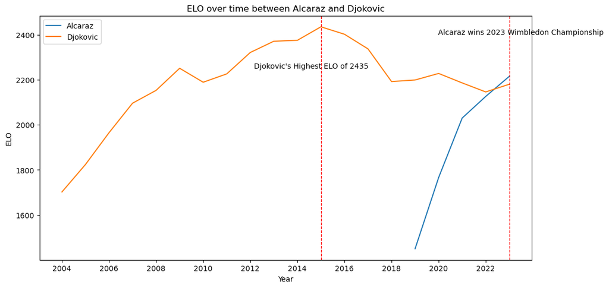

```python
# Plot to show ELO over time
plt.figure(figsize=(12,6))
plt.title("ELO over time between Alcaraz and Djokovic")
plt.plot(alcaraz_year_rankings['Year'], alcaraz_year_rankings['Elo'], label="Alcaraz")
plt.plot(djokovic_year_rankings['Year'], djokovic_year_rankings['Elo'], label="Djokovic")
plt.xlabel("Year")
plt.ylabel("ELO")
plt.legend()
plt.xticks(np.arange(2004, 2024, 2))

# Annotations to add for the July 2023 Wimbledon
wimbledon_month = 7 # July
year = 2023
x_coordinate = year + (wimbledon_month - 1) / 12.0
description = "Alcaraz wins 2023 Wimbledon Championship"
plt.axvline(x=year, color="red", linestyle="--", linewidth=1)
plt.text(x_coordinate, 2400, description, ha="center", fontsize=10)

# Annotations to add for the Djokovic's Highest Career ELO
year = 2015
description = "Djokovic's Highest ELO of 2435"
plt.axvline(x=year, color="red", linestyle="--", linewidth=1)
plt.text(year - .4, 2250, description, ha="center", fontsize=10)

plt.show()
```

Next, we will be performing some comparative analysis on the two players based on surfaces. We will be looking at how surfaces affect their winning changes over the last 52 weeks and their entire careers. This helps us see if any player demonstrates a specific strength or deficiency at any surface. Furthermore, the win percentage on grass will be especially important because Wimbledon is one of the few major tournaments that play on grass.

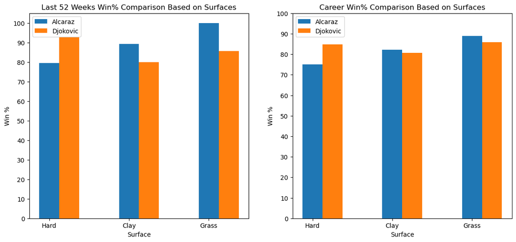

```python
# Here we are only looking at the surfaces
surfaces = ['Hard', 'Clay', 'Grass']

# Filter out the rows to isolate the relevant surfaces
alcaraz_52_surfaces = alcaraz_52_splits[alcaraz_52_splits['Split'].isin(surfaces)]
djokovic_52_surfaces = djokovic_52_splits[djokovic_52_splits['Split'].isin(surfaces)]
alcaraz_career_surfaces = alcaraz_career_splits[alcaraz_career_splits['Split'].isin(surfaces)]
djokovic_career_surfaces = djokovic_career_splits[djokovic_career_splits['Split'].isin(surfaces)]

# We will be creating two side by side bar plots so it will be in subplots
fig, axes = plt.subplots(nrows=1, ncols=2, figsize=(14, 6))
# The first plot will only be for the 52 weeks
ax1 = axes[0]
bar_width = 0.25

# Furthermore, the bar plots will have two bars for each category for comparison betweenAlcaraz and Djokovic
x_alcaraz = np.arange(len(surfaces))
x_djokovic = x_alcaraz + bar_width

# Adding the bar with labels for the legend
ax1.bar(x_alcaraz, alcaraz_52_surfaces["Win%"], width=bar_width, label="Alcaraz")
ax1.bar(x_djokovic, djokovic_52_surfaces["Win%"], width=bar_width, label="Djokovic")

# Setting the categorical labels in the x axis
ax1.set_xticks(x_alcaraz)
ax1.set_xticklabels(surfaces)

# Setting the axis labels and title
ax1.set_title("Last 52 Weeks Win% Comparison Based on Surfaces")
ax1.set_xlabel("Surface")
ax1.set_ylabel("Win %")
ax1.set_yticks(np.arange(0, 110, 10))
ax1.legend()

# Career Win % based on surfaces
# Repeat the same process
ax2 = axes[1]

ax2.bar(x_alcaraz, alcaraz_career_surfaces["Win%"], width=bar_width, label="Alcaraz")
ax2.bar(x_djokovic, djokovic_career_surfaces["Win%"], width=bar_width, label="Djokovic")

# Set the categorical labels
ax2.set_xticks(x_alcaraz)
ax2.set_xticklabels(surfaces)

# Setting the axis labels and title
ax2.set_title("Career Win% Comparison Based on Surfaces")
ax2.set_xlabel("Surface")
ax2.set_ylabel("Win %")
ax2.set_yticks(np.arange(0, 110, 10))
ax2.legend()

plt.show()
```

The results above were very surprising to me because I was under the impression that Djokovic was the strongest on grass surfaces. But it turns out he seems to be better on hard surfaces. I will discuss this more in the insight part of this final tutorial.

Next, we will be looking at how the players perform based on tournaments. This will give us insight on how well they do on other major matches and if they are consistent players or not.

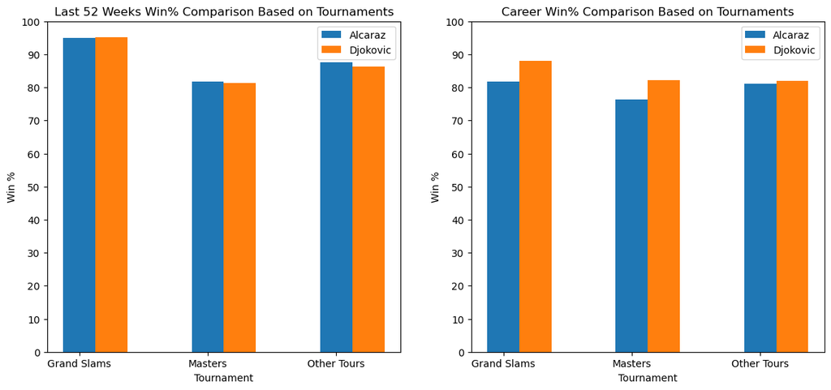

```python
# Here we are only looking at the tournaments
tournaments = ["Grand Slams", "Masters", "Other Tours"]
alcaraz_52_tournaments = alcaraz_52_splits[alcaraz_52_splits['Split'].isin(tournaments)]
djokovic_52_tournaments = djokovic_52_splits[djokovic_52_splits['Split'].isin(tournaments)]
alcaraz_career_tournaments = alcaraz_career_splits[alcaraz_career_splits['Split'].isin(tournaments)]
djokovic_career_tournaments = djokovic_career_splits[djokovic_career_splits['Split'].isin(tournaments)]


fig, axes = plt.subplots(nrows=1, ncols=2, figsize=(14, 6))
# The first plot will only be for the 52 weeks
ax1 = axes[0]
bar_width = 0.25

x_alcaraz = np.arange(len(tournaments))
x_djokovic = x_alcaraz + bar_width

# Adding the bar with labels for the legend
ax1.bar(x_alcaraz, alcaraz_52_tournaments["Win%"], width=bar_width, label="Alcaraz")
ax1.bar(x_djokovic, djokovic_52_tournaments["Win%"], width=bar_width, label="Djokovic")

ax1.set_xticks(x_alcaraz)
ax1.set_xticklabels(tournaments)

# Setting the axis labels and title
ax1.set_title("Last 52 Weeks Win% Comparison Based on Tournaments")
ax1.set_xlabel("Tournament")
ax1.set_ylabel("Win %")
ax1.set_yticks(np.arange(0, 110, 10))
ax1.legend()


# Career Win % based on tournaments
# Repeat the same process
ax2 = axes[1]

ax2.bar(x_alcaraz, alcaraz_career_tournaments["Win%"], width=bar_width, label="Alcaraz")
ax2.bar(x_djokovic, djokovic_career_tournaments["Win%"], width=bar_width, label="Djokovic")

ax2.set_xticks(x_alcaraz)
ax2.set_xticklabels(tournaments)

# Setting the axis labels and title
ax2.set_title("Career Win% Comparison Based on Tournaments")
ax2.set_xlabel("Tournament")
ax2.set_ylabel("Win %")
ax2.set_yticks(np.arange(0, 110, 10))
ax2.legend()

plt.show()
```

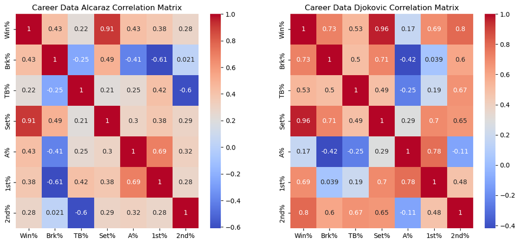

```python
# The heatmap only works for quantitative values
# Furthermore, the features should be somewhat related to each other
selected_columns = ["Win%", "Brk%", "TB%", "Set%", "A%", "1st%", "2nd%"]

# Select the columns that have the features
alcaraz_heatmap = alcaraz_career_splits[selected_columns]
djokovic_heatmap = djokovic_career_splits[selected_columns]

# Make the heat map and plot it
alcaraz_corr_matrix = alcaraz_heatmap.corr()
djokovic_corr_matrix = djokovic_heatmap.corr()

fig, axes = plt.subplots(1, 2, figsize=(14,6))
ax1, ax2 = axes

# Use seaborn for the heatmap
sns.heatmap(alcaraz_corr_matrix, annot=True, cmap="coolwarm", ax=ax1)
ax1.set_title("Career Data Alcaraz Correlation Matrix")

sns.heatmap(djokovic_corr_matrix, annot=True, cmap="coolwarm", ax=ax2)
ax2.set_title("Career Data Djokovic Correlation Matrix")

plt.show()
```

The correlation matrix above indicates whether a statistic has a positive or negative relationship with other data. This allows us to determine what factors are important in influencing the probability of winning a match. As expected, there is a positive correlation between certain variables such as between win% and break% or between win% and set%. This is because this is the most important factor in influencing the outcome of a game. It is expected that a player with a higher break or set percentage will have a higher win percentage. Similarly, a player that aces more often is slightly correlated to having a higher win chance. The correlation matrix demonstrates how these game statistics influences a player's chances of winning.

Interestingly, it seems that some features have a difference influence on win% compared to other players. For example, Break % and Set % seem more influential to Djokovic's win % than it is for Alcaraz's win %. The differences in the correlation between the players indicates that they have different playstyles and strengths. For example, Alcaraz seems to have a stronger correlation with ace % and win %, which could indicate he relies more heavily on aces.

## Part 4: Further Analysis & Predictions

We will be using a Logistic Regression model to make a prediction on the outcome of another game between Alcaraz and Djokovic. Logistic Regression models are especially applicable in situations that involve binary classification. The model uses the parameters of the features and trains itself to determine the weights. Finally, it determines the odds of winning and classifies who is predicted to win. Logistic models are simple but very useful tools to predict binary outcomes.

In this case, I want to predict the outcome of today's game, which is in the Cincinnati Masters. It is played on hard court, so I will use data on that for each player.

```python
features = ["Player", "tournament", "Surface", "Round", "Player Rank", "Opponent Rank", "Duration"]

# For both players, we are dropping the unnecessary columns and making the outcome into a string
alcaraz_matches = alcaraz_matches.drop(axis=1, labels=["Date", "Score", "More", "Time"])
alcaraz_matches["Outcome"] = alcaraz_matches["Outcome"].astype(str)

djokovic_matches = djokovic_matches.drop(axis=1, labels=["Date", "Score", "More", "Time"])
djokovic_matches["Outcome"] = djokovic_matches["Outcome"].astype(str)

# Drop the live in progress game
alcaraz_matches = alcaraz_matches.tail(-1)
djokovic_matches = djokovic_matches.tail(-1)

# Here, we are changing the outcome to whether the player won or not instead of the standard notation
def get_outcome(player, row):
    if player in row["Outcome"] and row["Outcome"].find(player) < row["Outcome"].find("d."):
        return "Win"
    else:
        return "Lose"

# Apply the function to get if they win or lose
alcaraz_matches["Outcome"] = alcaraz_matches.apply(lambda row: get_outcome("Alcaraz", row), axis=1)
djokovic_matches["Outcome"] = djokovic_matches.apply(lambda row: get_outcome("Djokovic", row), axis=1)

alcaraz_matches.head()
```

|  | Tournament | Surface | Rd | Rk | vRk | Outcome | TP | Aces | DFs | SP | 1SP | 2SP | vA |
| --- | --- | --- | --- | --- | --- | --- | --- | --- | --- | --- | --- | --- | --- |
| 1 | Cincinnati | Hard | SF | 1.0 | 20.0 | Win | 198.0 | 2.0 | 0.0 | 91.0 | 60.0 | 31.0 | 10.0 |
| 2 | Cincinnati | Hard | QF | 1.0 | 70.0 | Win | 191.0 | 6.0 | 8.0 | 89.0 | 52.0 | 37.0 | 10.0 |
| 3 | Cincinnati | Hard | R16 | 1.0 | 13.0 | Win | 255.0 | 6.0 | 4.0 | 103.0 | 67.0 | 36.0 | 11.0 |
| 4 | Cincinnati | Hard | R32 | 1.0 | 55.0 | Win | 212.0 | 3.0 | 5.0 | 86.0 | 47.0 | 39.0 | 4.0 |
| 5 | Canada Masters | Hard | QF | 1.0 | 14.0 | Lose | 186.0 | 4.0 | 6.0 | 99.0 | 66.0 | 33.0 | 2.0 |

```python
# Label the players
# In terms of training, this is not necessary for the model
# However, it will allow you to inspect the data if you want to
alcaraz_matches["Player"] = "Alcaraz"
djokovic_matches["Player"] = "Djokovic"

# Concatenate the two dataframes
all_matches = pd.concat([alcaraz_matches, djokovic_matches], ignore_index=True)

# Only get the rows of games on hard surfaces
hard_surface_matches = all_matches[all_matches["Surface"] == "Hard"].copy()

# Set the value to 1 if they win or 0 if they lose
# Needed to be numeric for training
hard_surface_matches["Outcome"] = hard_surface_matches["Outcome"].apply(lambda x: 1 if x == "Win" else 0)

hard_surface_matches.head()
```

|  | Tournament | Surface | Rd | Rk | vRk | Outcome | TP | Aces | DFs | SP | 1SP | 2SP | vA | Player |
| --- | --- | --- | --- | --- | --- | --- | --- | --- | --- | --- | --- | --- | --- | --- |
| 0 | Cincinnati | Hard | SF | 1.0 | 20.0 | 1 | 198.0 | 2.0 | 0.0 | 91.0 | 60.0 | 31.0 | 10.0 | Alcaraz |
| 1 | Cincinnati | Hard | QF | 1.0 | 70.0 | 1 | 191.0 | 6.0 | 8.0 | 89.0 | 52.0 | 37.0 | 10.0 | Alcaraz |
| 2 | Cincinnati | Hard | R16 | 1.0 | 13.0 | 1 | 255.0 | 6.0 | 4.0 | 103.0 | 67.0 | 36.0 | 11.0 | Alcaraz |
| 3 | Cincinnati | Hard | R32 | 1.0 | 55.0 | 1 | 212.0 | 3.0 | 5.0 | 86.0 | 47.0 | 39.0 | 4.0 | Alcaraz |
| 4 | Canada Masters | Hard | QF | 1.0 | 14.0 | 0 | 186.0 | 4.0 | 6.0 | 99.0 | 66.0 | 33.0 | 2.0 | Alcaraz |

```python
# Ensure there are no null values so that the models can be fitted without problems
numeric_columns = hard_surface_matches.select_dtypes(include=[np.number])
hard_surface_matches = hard_surface_matches.fillna(numeric_columns.median())
hard_surface_matches.isnull().sum()
```

```
Tournament    0
Surface       0
Rd            0
Rk            0
vRk           0
Outcome       0
TP            0
Aces          0
DFs           0
SP            0
1SP           0
2SP           0
vA            0
Player        0
dtype: int64
```

```python
# Separate only the relevant features of the model
features = ["Rk", "vRk", "TP", "Aces", "DFs", "SP", "1SP", "2SP", "vA"]
X = hard_surface_matches[features]
y = hard_surface_matches["Outcome"]

# Split the data with 80% training and 20% testing
X_train, X_test, y_train, y_test = train_test_split(X, y, test_size=0.2)

# Ptiny out the shape of the input
X_train.shape, X_test.shape, y_train.shape, y_test.shape
```

```
((740, 9), (186, 9), (740,), (186,))
```

Here are some documentation on Logistic Regression:

- [Scikit-Learn Docs](https://scikit-learn.org/stable/modules/generated/sklearn.linear_model.LogisticRegression.html)
- [Logistic Regression Explanation](https://www.ibm.com/topics/logistic-regression#:~:text=Resources-,What%20is%20logistic%20regression%3F,given%20dataset%20of%20independent%20variables.)

```python
# Create the model and fit it based on the training data
logistic_reg = LogisticRegression(max_iter=10000)
logistic_reg.fit(X_train, y_train)

# Make predictions and validate the accuracy
y_pred = logistic_reg.predict(X_test)

accuracy = accuracy_score(y_test, y_pred)
print(accuracy)
```

```
0.8494623655913979
```

```python
features = ["Rk", "vRk", "TP", "Aces", "DFs", "SP", "1SP", "2SP", "vA"]

# Game statistics extrapolated from previous games between Alcaraz and Djokovic
game_statistics = pd.DataFrame({
    "Rk": [1],
    "vRk": [2],
    "TP": [334],
    "Aces": [9],
    "DFs": [7],
    "SP": [150],
    "1SP": [94],
    "2SP": [56],
    "vA": [3],
})

# An output of 1 represents Alcaraz winning and Djokovic winning
logistic_reg.predict(game_statistics)
```

```
array([1])
```

The logistic regression is predicting that Alcaraz is favored to win. Good luck to both players in the real game!

## Part 5: Insight

The data science process can be incredibly insightful as they in some cases reaffirm expectations or completely surprise you. In this case, I found that several of my ideas behind player's strengths were unfounded and they played better in other regards.

It seems that the predictions are that Alcaraz is favored to win once again. This seems to support my thoughts of the new generation of tennis talent taking over the previous generation. However, the outcome of the real game is only for time to tell. Regardless of whether this prediction is incorrect or not, I hope that you learned a lot from the process. I certainly learned a great deal of tennis statistical analysis.

### How is this Useful?

These forms of player and match analysis can be useful in many different ways. For example, if one wanted to bet on a certain player winning a match, then it would be beneficial for them to perform this analysis and determine whether their bets are founded on statistics. Another example could be that a coach is looking for ways to improve their player's performance. They can find areas that need improvement or opportunities that provide marginal benefits to the player by performing this analysis. These data analysis processes are incredibly insightful into the player's performance and they can give completely unexpected results and provide deeper knowledge on the player's strengths.

Furthermore, this form of analysis is not limited to only tennis. This can be done in other sports such as soccer, basketball, swimming, etc. Evidently, there are many different fields and sports where data science is incredibly useful. When done correctly, the benefits can be incredible like that of in Moneyball.

I hope that you have learned from my final tutorial, and thank you so much for taking the time to read it!